# TSA Final Exam

Mary Esther Nevener

May 7, 2020

## TIME SERIES ANALYSIS FINAL EXAM

### PROBLEM 1

1. [20pts] Consider the MA model $Z_T=0.5+\epsilon_t+\epsilon_{t-1}+\epsilon_{t-2}$
1. Compute the theoretical ACF and plot it
2. Generate $Z_t$ for $1\leq t \leq 1000$ and plot $Z_t$
3. Compute the empirical ACF using the samples and compare it with your answer from (a)

#### 1a)

$$Z_T=0.5+\epsilon_t+\epsilon_{t-1}+\epsilon_{t-2}\\
\mu=0.5, \theta_1=1, \theta_2 =1\\
\gamma_0=(1+\theta_1^2+\theta_2^2) \sigma^2 = 3 \sigma^2\\
\gamma_1= (\theta_1+\theta_2\theta_1)\sigma^2 =2\sigma^2\\
\gamma_2=\theta_2\sigma^2 =\sigma_2\\
\rho_1=\frac{\theta_1 + \theta_1\theta_2}{1+\theta_1^2+\theta_2^2}=\frac{2}{3}\\
\rho_2=\frac{\theta_2}{1+\theta_1^2+\theta_2^2}=\frac{1}{3}\\$$

```r
acfma2=ARMAacf(ma=c(1,1), lag.max=10)
acfma2
```

```
##         0         1         2         3         4         5         6         7
## 1.0000000 0.6666667 0.3333333 0.0000000 0.0000000 0.0000000 0.0000000 0.0000000
##         8         9        10
## 0.0000000 0.0000000 0.0000000
```

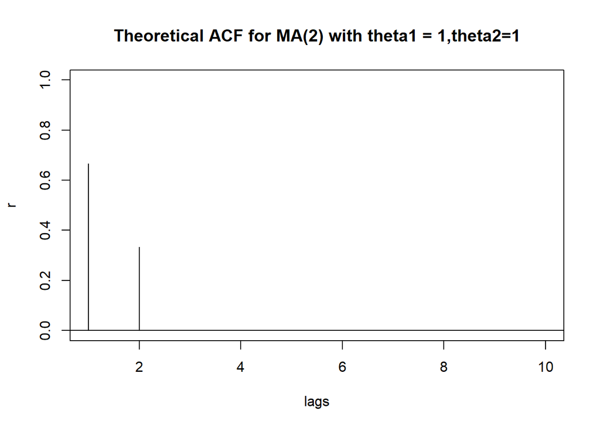

```r
lags=0:10
plot(lags,acfma2,xlim=c(1,10), ylab="r",type="h", main = "Theoretical ACF for MA(2) with theta1 = 1,theta2=1")
abline(h=0)
```

#### 1b)

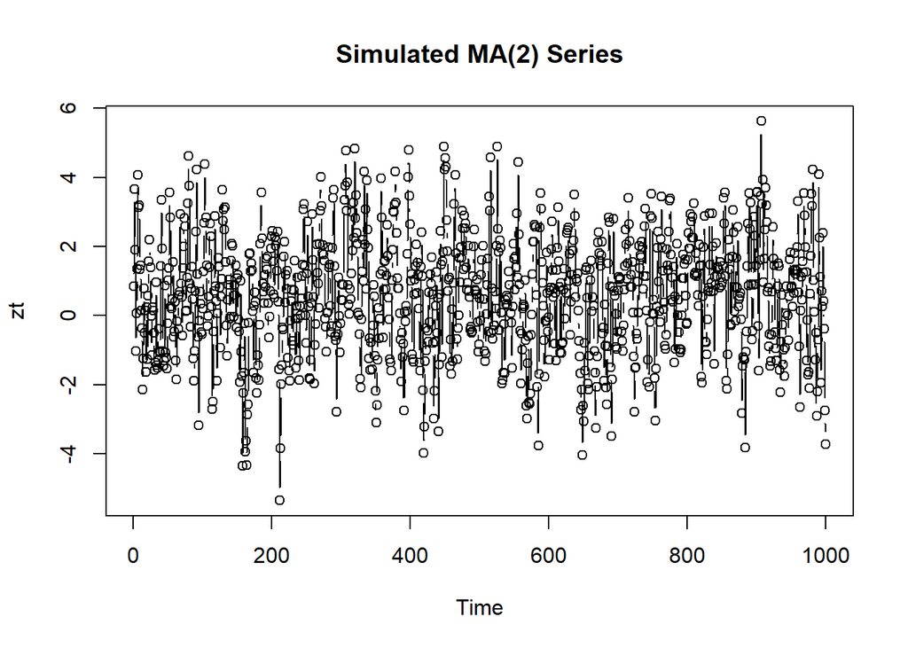

```r
zc=arima.sim(n=1000, list(ma=c(1, 1)))
zt=zc+.5
plot(zt, type="b", main = "Simulated MA(2) Series")
```

#### 1c)

##### There are two statistically significant spikes at lags 1 and 2 followed by non-significant values for other lags. However, due to sampling error, the sample ACF did not match the theoretical pattern exactly.

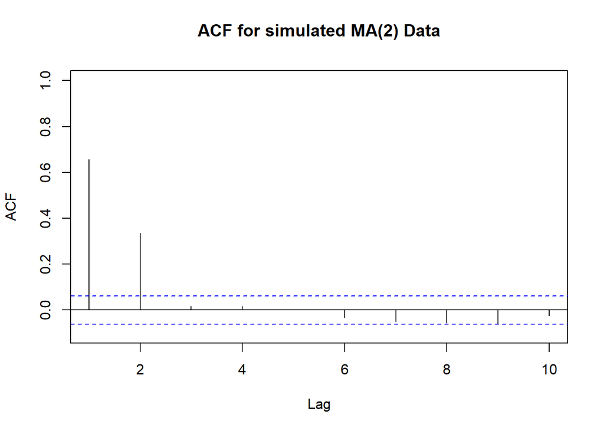

```r
acf(zt, xlim=c(1,10), main="ACF for simulated MA(2) Data")
```

### PROBLEM 4

4. [20pts] Prove that conditional expectation minimizes the mean square error.

**PROOF:**

> Let our estimate $\hat{x}$ be a function of our known $y$ such that $\hat{x}=g(y)$. The error of our estimate is given by $\widetilde{X}=X-\hat{x}=X-g(y)$. The mean square error of our estimate is given by $E[(X-\bar{x})^2|Y=y]=E[(X-g(y))^2|Y=y]$. By using calculus we can calculate the minimun MSE.
> $$\begin{align*}
> \text{MSE} &=E[(X-\hat{x})^2|Y=y]\\
> &= E[X^2|Y=y]-2\hat{x}E[X|Y=y]+\hat{x^2}\\
> \text{MSE'} &= -2E[X|Y=y]+2\hat{x}=0\\
> \hat{x}_{\text{MIN}} &= E[X|Y=y]
> \end{align*}$$
> Suppose that we would like to estimate the value of an unobserved random variable $X$, by observing the value of a random variable $Y=y$. In general, our estimate $\hat{x}$ is a function of $y$, so $\hat{X}=g(Y)$. Since $Y$ is a random variable, $\hat{X}=g(Y)$ is also a random variable. The error of our estimate is given by $\tilde{X}=X-\bar{X}=X-g(Y)$. The mean square error of our estimate is given by $E[(X-\hat{X})^2]=E[(X-g(Y))^2]$. By using calculus we can calculate the minimun MSE.
> $$\begin{align*}
> \text{MSE} &=E[(X-\hat{X})^2|Y]\\
> &= E[X^2|Y]-2\hat{X}E[X|Y]+\hat{X^2}\\
> \text{MSE'} &= -2E[X|Y]+2\hat{X}=0\\
> \hat{X}_{\text{MIN}} &= E[X|Y]
> \end{align*}$$

**END PROOF.**

### PROBLEM 5

5. [20pts] Compute expressions for the partial autocorrelation function for AR(1) and MA(1) models.

$$\textbf{AR(1)}\\
x_t=\phi x_{t-1}+\epsilon_{t}\\
|\phi|\lt 1\\
\text{var}(\epsilon_t)=\sigma^2\\
\text{var}(x_t)=\frac{\sigma^2}{1-\phi^2}\\$$

$$\textbf{PACF FOR AR(1)}\\
\begin{align*}
\phi_{11}&=\frac{cov(x_t,x_{t+1})}{var(x_t)}\\
&=\frac{E[\phi x_{t-1}+\epsilon_t)x_{t-1}]}{var(x_t)}\\
&= \phi \frac{var(x_t)}{var(x_t)}\\
&= \phi\\
cov(e_t,e_{t+2})&= E[(x_t-\phi x_{t+1})(x_{t+2}-\phi x_{t+1})]\\
&= E[(x_t-\phi x_{t+1})\epsilon_{t+2}]\\
&=0\\
\phi_{22}&=\frac{cov(e_t,e_{t+2})}{[var(e_t)var(e_{t+2})]^\frac{1}{2}}\\
&= 0\\
\phi_{kk}&=0 \text{ for all k } \geq 2
\end{align*}$$

$$\textbf{MA(1)}\\
x_t=\epsilon_t+\theta\epsilon_{t-1}\\
var(x_t)=(1+\theta^2)\sigma^2\\
E[x_t.x_{t+1}]=\theta\sigma^2\\
E[x_t.x_{t+2}]=0\\$$

$$\textbf{PACF FOR MA(1)}\\
\begin{align*}
\phi_{11}&=\frac{E[x_t,x_{t+1}]}{var(x_t)}\\
&=\frac{\theta}{1+\theta^2}\\
\text{E}[e_t,e_{t+2}]&=\text{E}\big[ (x_t-\alpha x_{t+1})(x_{t+2}-\alpha x_{t+1})\big]\\
&=\text{E}[x_tx_{t+2}]-\alpha \text{E}[x_tx_{t+1}] - \alpha \text{E}[x_{t+1}x_{t+2}] -\alpha^2 \text{E}[x_{t+1}^2] \\
&= 0 -\alpha\theta\sigma^2 -\alpha\theta\sigma^2 + \alpha^2(1+\theta^2)\sigma^2\\
&=-\frac{2\theta^2}{(1+\theta^2)}\sigma^2+\frac{\theta^2\sigma^2}{(1+\theta^2)}\\
&=-\frac{\theta^2\sigma^2}{1+\theta^2}\\
\text{var}(e_t)&=\text{E}[x_t-\alpha x_{t+1}]^2\\
&= \text{E}(x_t^2)-2\alpha\text{E}(x_t x_{t+1})+ \alpha^2 \text{E}(x_{t+1}^2)\\
&= (1+\theta^2)\sigma^2-2\alpha \theta\sigma^2 + \alpha^2(1+\theta^2)\sigma^2\\
&= \frac{\sigma^2}{(1+\theta^2)}\big[1+\theta^2+\theta^4\big] \\
\text{var}(e_{t+2})&=\text{E}[x_{t+2}-\alpha x_{t+1}]^2\\
&= \text{E}(x_{t+2}^2)-2\alpha\text{E}(x_{t+2} x_{t+1})+ \alpha^2 \text{E}(x_{t+1}^2)\\
&= (1+\theta^2)\sigma^2-2\alpha \theta\sigma^2 + \alpha^2(1+\theta^2)\sigma^2\\
&= \frac{\sigma^2}{(1+\theta^2)}\big[1+\theta^2+\theta^4\big] \\
\phi_{22}&=\frac{E[e_te_{t+2}]}{\big[\text{var}(e_t)\text{var}(e_{t+2})\big]^{\frac{1}{2}}}\\
&=-\frac{\theta^2}{(1+\theta^2+\theta^4)} \\
\phi_{kk}&=\frac{(-1)^{k-1}\theta^k(1-\theta^2)}{1-\theta^{2(k+1)}}\\
\end{align*}$$

### PROBLEM 2

2. [20pts] Download 1 time series containing trend and seasonality from http://www.statsci.org/datasets.html
1. Plot each series and compute its ACF and PACF
2. Based on the ACF and PACF, pick 2 distinct models and estimate their parameters
3. Compare the residual for each model
4. Which model is better and why?

### PROBLEM 3

3. [20pts] Derive an expression for the power spectral density,$s_y(\omega)$ for the ARMA(1,1) model and plot $s_y(\omega)$ for $0 \leq \omega \leq \pi$

$$\textbf{POWER SPECTRAL DENSITY ARMA(1,1)}$$

$$\begin{align*}
\Phi(L)(y_t-\mu)&=\Psi(L)\epsilon_t\\
\Phi(L)&=1-\phi L\\
\Psi(L)&=1+\theta L\\
\therefore (y_t-m)&=\frac{\Psi(L)}{\Phi(L)}\epsilon_t=\bar{\psi}(L)\epsilon_t\\
g_y(z)&=\sigma^2\bar{\psi}(z)\bar{\psi}(z^{-1})\\
s_y(\omega)&=\frac{\sigma^2}{2\pi}\bar{\psi}(e^{-i\omega})\bar{\psi}(e^{i\omega})\\
\text{after factoring}\\
\Phi(z)&=1-\alpha z\\
\Psi(z)&=1+\beta z\\
\text{after substituting}\\
s_y(\omega)&=\frac{\sigma^2}{2\pi}\frac{1+\theta^2-2\theta \text{ cos}( \omega)}{1+\phi^2-2\phi \text{ cos}( \omega)}\\
\text{after normalizing}\\
\frac{2\pi}{\sigma^2}s_y(\omega)&=\frac{1+\theta^2-2\theta \text{ cos}( \omega)}{1+\phi^2-2\phi \text{ cos}( \omega)}\\
\end{align*}$$
$$\textbf{GRAPHING}\\
\begin{matrix}
\omega=0 & \to & s_y(w)=\frac{(\theta-1)^2}{(\phi-1)^2}\\
\omega=\frac{\pi}{2} & \to & s_y(w)=\frac{\theta^2+1}{\phi^2+1}\\
\omega=\pi & \to & s_y(w)=\frac{(\theta+1)^2}{(\phi+1)^2}\\
\end{matrix}$$